# 6 Distributions de probabilités

- Montrer tout le code
- Cacher tout le code

Auteur

Affiliation

Daniel Coulombe

Institut des Sciences, Technologies et Études Avancées d’Haïti (ISTEAH)

Date

28/03/2024

## 6.1 Introduction

Dans les chapitres précédents, nous avons examiné de quelle manière on pouvait calculer la probabilité d’occurrence de différents événements faisant partie d’un espace échantillonnal. L’étape suivante consiste à obtenir la probabilité d’occurrence de chacun des événements possible lors d’une expérience aléatoire. Le résultat de cet exercice est une **distribution de probabilités**, le sujet du présent chapitre.

## 6.2 La distribution des probabilités

Si une pièce de monnaie n’est pas trafiquée ($p=0.5$), on peut accepter le fait que la probabilité d’obtenir le côté ‘FACE’ lors d’un lancer de cette pièce soit égale à 0.5. On a une chance sur deux d’obtenir ce côté. Si on lance plusieurs pièces, n = 5 par exemple, chaque pièce a une chance égale de tomber du côté ‘FACE’, et les résultats possibles pour une telle expérience sont l’un ou l’autre de 0, 1, 2,3, 4 ou 5 FACES… Vérifions cela. Le code suivant répète 100 fois le lancer de 5 pièces de monnaie, et on comptabilise à chaque essai le nombre de FACES apparaissant, et la Table 6.1 (onglet libellé *Distribution*) résume les résultats obtenus, qui sont affichés dans la Figure 6.1 (onglet libellé *Diagramme*)

**Distribution**

```r
# Simulation du lancer de n pièces de monnaie
# Compilation de la distribution de probabilités
#
set.seed(150752)
nt <- 100           # Nombre d'essais
No_Pieces <- 5      # Nombre de pièces
res <- replicate(nt,
                 sum(CoinToss(No_Pieces, 0.5) == "Face"))
Freq  <-  as.matrix(table(res))# Fréquences
Prop <- Freq / sum(Freq)       # Proportions
Faces <- sort(unique(res))
tbl  <-  data.frame(Faces, Freq, Prop)

tbl %>%
  kbl(booktabs=TRUE,
      row.names=FALSE) %>%
  kable_styling(bootstrap_options = c("striped", "hover", "condensed"),
                full_width=FALSE)
```

Table 6.1: Distribution du nombre de FACEs observé pour le lancer de 5 pièces de monnaie

| Faces | Freq | Prop |
| --- | --- | --- |
| 0 | 3 | 0.03 |
| 1 | 14 | 0.14 |
| 2 | 33 | 0.33 |
| 3 | 34 | 0.34 |
| 4 | 13 | 0.13 |
| 5 | 3 | 0.03 |

**Diagramme**

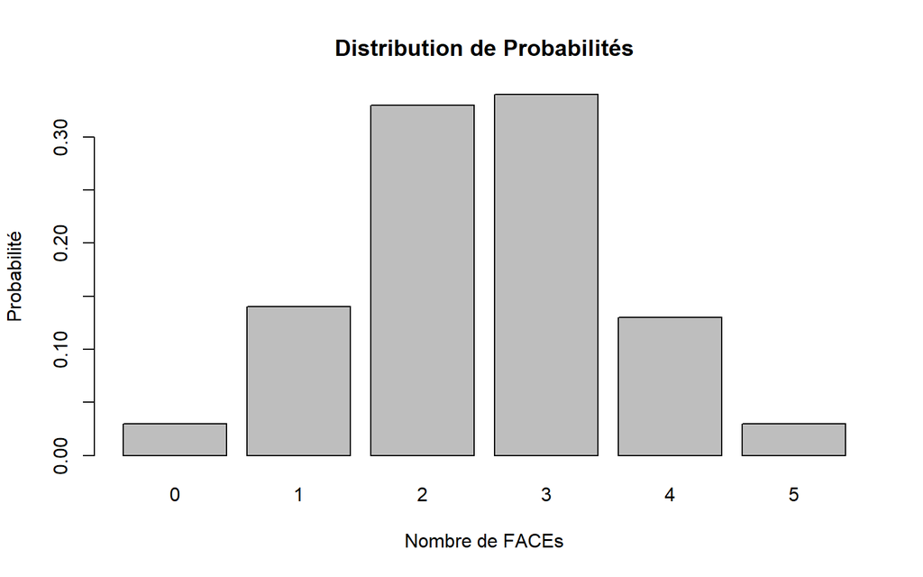

Figure 6.1: Distribution de Probabilités (lancer de 5 pièces de monnaie)

Du diagramme et du tableau obtenus, on note qu’on a plus de chance d’obtenir 2-3 FACEs en lançant 5 pièces de monnaie, qu’un nombre plus élevé ou inférieur. Mais les événements plus extrêmes ne sont pas exclus: il peut arriver que l’on n’obtienne aucune FACE, ou qu’on en obtienne 5. De tels résultats sont simplement plus rares, ou moins probables.

Reprenons l’expérience, mais en la répétant 100,000 fois! Pour permettre le changement rapide du nombre d’essais, la variable **No_essais** a été créée. Il vous suffira de changer sa valeur pour spécifier le nombre d’essais à effectuer. Les résultats de cette expérience sont résumés dans le Table 6.2 et la Figure 6.2.

**Distribution**

```r
set.seed(150752)
No_essais <- 100000  # Spécification du nombre d'essais à effectuer
No_Pieces <- 5       # Nombre de Pièces
res <- replicate(No_essais,
                 sum(CoinToss(No_Pieces, 0.5) == "Face"))
Freq <- as.matrix(table(res))   # Production du tableau de fréquences
Prop <- Freq[, 1]/No_essais     # Fréquence relative (Probabilités)
x <- sort(unique(res))

tbl <- data.frame(x,Freq,Prop)
espm <- sum(x*Prop)             # Calcul de l'expérance mathématique
tbl %>%
  kbl(booktabs=TRUE,
      row.names=FALSE,
      digits=3) %>%
  kable_styling(full_width = FALSE)
```

Table 6.2: Distribution du nombre de FACEs

| x | Freq | Prop |
| --- | --- | --- |
| 0 | 3222 | 0.032 |
| 1 | 15730 | 0.157 |
| 2 | 31181 | 0.312 |
| 3 | 31423 | 0.314 |
| 4 | 15401 | 0.154 |
| 5 | 3043 | 0.030 |

**Diagramme**

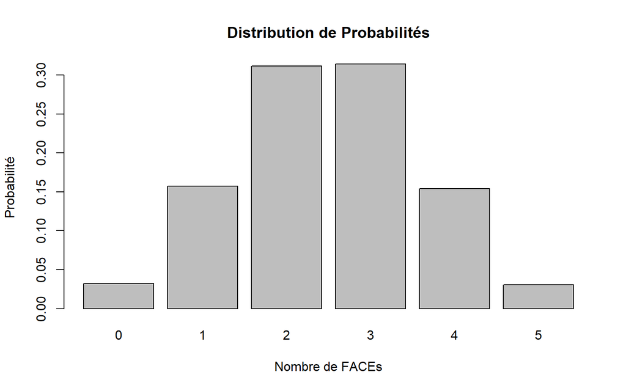

Figure 6.2: Distribution de Probabilités (lancer de 5 pièces de monnaie)

Pour répondre à une question telle que: ‘**Combien de fois obtenons-nous 4 FACES ou PLUS, en lançant 5 pièces de monnaie non trafiquées**?’, on pourrait simplement additionner les fréquences correspondant à x = 4 et x = 5. Ou on pourrait directement obtenir ce nombre à partir de l’ensemble des résultats obtenus. On utilisera ici l’opérateur logique ‘**>=**’ , qui accorde une valeur ‘1’ ou ‘TRUE’ si x (le nombre de FACES) est supérieur ou égal à l’argument de droite (4):

```r
sum(res >= 4 )
```

```
#> [1] 18444
```

Connaissant le nombre de FACEs qui nous intéresse (x = 4 ou x = 5), on peut aisément calculer la probabilité recherchée. Puisque 100,000 expériences aléatoires ont été effectuées, il suffira de diviser ce nombre par le nombre total de résultats obtenus [**length(res)**], qui est égal à 100,000:

```r
sum(res >= 4) / length(res)
```

```
#> [1] 0.18444
```

On obtiendra évidemment le même résultat en utilisant la fonction **mean()**, puisque la moyenne d’une variable binaire est une proportion (probabilité):

```r
mean(res>=4)
```

```
#> [1] 0.18444
```

La distribution de probabilités que nous sommes maintenant en mesure de définir possède certaines caractéristiques importantes. D’une part, elle a une forme: les différents événements (axe horizontal) ne sont pas tous équiprobables. La forme peut être symétrique ou non, selon le cas.

D’autre part, elle a une certaine étendue ou dispersion: dans le cas présent, les résultats s’étendent de 0 jusqu’à 5.

Et finalement, elle a un centre, situé entre les deux valeurs extrêmes. Ce centre nous permettrait de répondre à une question telle que: ‘En lançant 5 pièces de monnaie, combien de **FACEs** puis-je m’attendre à obtenir, si je répétais l’expérience un nombre infini de fois?’. La forme nous indique que les résultats (nombre de FACEs) ne sont pas équiprobables. Quel serait, alors, le résultat le plus probable? Le terme désignant cette caractéristique est: **espérance mathématique**. Mathématiquement, combien de FACEs peut-on espérer obtenir en lançant 5 pièces de monnaie? On sait que ce nombre est compris entre 0 et 5. On peut obtenir la probabilité de chacun de ces résultats. L’espérance mathématique est alors la somme du produit de la probabilité d’obtenir un résultat particulier et la valeur de ce résultat. En termes plus formels:

$$E(X)=\sum_{X=0}^{n} XP(X) \tag{6.1}$$

Si on considère la distribution de probabilités obtenue par simulation et reproduite dans le Table 6.2, on trouve:

$$E(X)=2.4918$$

L’espérance mathématique de cette distribution, indiquée ci-dessus, est obtenue par:

$$(0\times 0.03222)+(1\times 0.1573)+(2\times 0.31181)+(3\times 0.31423)+(4\times 0.15401)+(5\times 0.03043)= 2.4918$$

Essentiellement, on peut s’attendre, en lançant 5 pièces de monnaie un nombre infini de fois, à obtenir 2.4918 faces en moyenne. En examinant le graphique correspondant à cette simulation, on note en effet que les deux valeurs les plus fréquentes (probables) sont 2 et 3 FACEs. Par contre, un tel résultat suppose une distribution symétrique. Lorsque la distribution est asymétrique, l’espérance mathématique ne correspond pas nécessairement à l’événement le plus fréquent.

## 6.3 La Loi des Grands Nombres

Pour fins d’illustration, le code R suivant répète la simulation pour un nombre de lancers de 5 pièces de monnaie variant entre 100 et 50,000, par étape de 100. Le temps d’exécution de l’exercice est un peu long (quelques minutes), mais permet d’illustrer la Loi des Grands Nombres. L’événement d’intérêt est ‘Nombre de FACEs supérieur à 3’. La Figure 6.3 reproduit les résultats.

[figure not shown]

Figure 6.3: Loi des Grands Nombres: P(X>3), pour le lancer de 5 pièces

```r
n_trials <- 100 * c(1:500)
pr <- numeric(length(n_trials))

for (i in seq_along(n_trials)) {
  successes <- sum(replicate(n_trials[i], sum(rbinom(5, 1, 0.5)) > 3))
  pr[i] <- successes / n_trials[i]  # Empirical probabilities
}

plot(pr,
     type="l",
     xlab="Essais (blocs de 100)",
     ylab="Probabilité X > 3")
abline(h=0.1875,
       lty = 2,
       lwd = 2,
       col="red")
```

Dans cette figure, on note manifestement l’augmentation de la précision en fonction du nombre d’essais. Plus le nombre d’essais est élevé, plus l’estimation de la probabilité recherchée est précise. L’estimation de $P(X>3)$ converge vers la probabilité théorique de cet événement, qui théoriquement est $P(X > 3)=0.1875$ (ligne horizontale rouge). Mais une question importante demeure: **comment peut-on obtenir cette valeur théorique?** Comment peut-on obtenir cette valeur sans avoir à simuler le processus?

## 6.4 Approche analytique: la distribution binomiale

Jusqu’à maintenant, nous avons considéré des expériences aléatoires dont les résultats étaient des événements discrets: un certain nombre de pièces de monnaie tombant sur le côté FACE, une valeur comprise entre 1 et 6 observée en lançant un dé, etc. Dans plusieurs cas, il était facile d’obtenir la probabilité qu’un événement survienne: la probabilité d’obtenir FACE en lançant une pièce de monnaie est 0.5, en lançant 2 pièces de monnaie, la probabilité d’obtenir 2 FACES est 0.5x0.5 = 0.25 (on applique ici la règle de multiplication des probabilités d’événements indépendants); en lançant un dé, la probabilité d’obtenir un 6 est 1/6, et la probabilité d’obtenir un 5 OU un 6 est 1/6+1/6 = 2/6 (on applique ici la règle d’addition des probabilités d’événements mutuellement exclusifs). Nous avons aussi utilisé la simulation afin d’obtenir des distributions de probabilités à partir desquelles on pouvait sans trop de difficultés obtenir les probabilités recherchées. Le résultat de telles simulations nous fournit une approximation de la probabilité réelle d’un événement, la précision de cette approximation étant déterminée par le nombre d’essais. C’est ce que la Loi des Grands Nombres démontre.

Dans le cas des situations impliquant des événements se traduisant par l’un de deux états (PILE/FACE, SUCCÈS/ÉCHEC, etc.) et dont les probabilités d’occurrence sont invariantes d’un essai à l’autre, la distribution de probabilités théorique appropriée est la distribution **binomiale**. Cette distribution permet d’obtenir les probabilités de tout événement de ce type, de manière analytique. Sous condition que certains postulats sont respectés, les probabilités sont en effet données par l’équation Équation 6.2.

$$f(x|n,p) = \frac{n!}{x!(n-x)!} p^x (1-p)^{n-x} = {{n}\choose{x}} p^x (1-p)^{n-x} \tag{6.2}$$

Croyez-le ou non, cette expression est simplement un rapport entre le nombre de ‘succès’ ($\frac{n!}{x!(n-x)!}$) divisé par le nombre total d’événements possibles ($p^x(1-p)^{n-x}$). Donc aucune différence notable par rapport aux définitions présentées antérieurement n’existe.

### 6.4.1 Lancers de pièces de monnaie et distribution binomiale

En reprenant l’exemple du lancer de 5 pièces de monnaie, le résultat des opérations décrites par cette équation se lit: ‘En lançant un nombre infini de fois $n= 5$ pièces de monnaie non truquées ($p = 0.5$), la probabilité d’obtenir *x* FACEs est égale à…’. En appliquant cette équation à chacun des résultats possibles au lancer de 5 pièces, on obtient:

$$f(0|5,0.5) = \frac{5!}{0!(5-0)!}\times 0.5^0 \times (1-0.5)^{5-0} = 0.03125$$
$$f(1|5,0.5) = \frac{5!}{1!(5-1)!}\times 0.5^1 \times (1-0.5)^{5-1} = 0.15625$$
$$f(2|5,0.5) = \frac{5!}{2!(5-2)!}\times 0.5^2 \times (1-0.5)^{5-2} = 0.31250$$
$$f(3|5,0.5) = \frac{5!}{3!(5-3)!}\times 0.5^3 \times (1-0.5)^{5-3} = 0.31250$$
$$f(4|5,0.5) = \frac{5!}{4!(5-4)!}\times 0.5^4 \times (1-0.5)^{5-4} = 0.15625$$
$$f(5|5,0.5) = \frac{5!}{5!(5-5)!}\times 0.5^5 \times (1-0.5)^{5-5} = 0.03125$$
De ces calculs, on trouve que la probabilité théorique de l’événement X > 3 est:

$$P(X>3) = P(X=4)+P(X=5) = 0.15625 + 0.03125 = 0.1875$$

une valeur qui ne contredit en rien le point de convergence observé par simulation. De plus, on note que les probabilités calculées pour chaque valeur possible de X sont presque identiques à celles obtenues par simulation dans la section Section 6.2, tel qu’illustré dans la Table 6.3.

Table 6.3: Distribution du nombre de Faces

| #Faces | Fréq | Prop | Pr Théor |
| --- | --- | --- | --- |
| 0 | 3222 | 0.03222 | 0.03125 |
| 1 | 15730 | 0.15730 | 0.15625 |
| 2 | 31181 | 0.31181 | 0.31250 |
| 3 | 31423 | 0.31423 | 0.31250 |
| 4 | 15401 | 0.15401 | 0.15625 |
| 5 | 3043 | 0.03043 | 0.03125 |

Il suffirait d’augmenter le nombre d’essais pour augmenter la précision des estimations et réduire l’écart existant entre les probabilités empiriques et les probabilités théoriques.

Notons que sous R, on peut obtenir ces probabilités en utilisant la fonction **dbinom(x, size, prob)**. Les arguments de cette fonction sont:

- **x** : un nombre ou un vecteur de nombre représentant les résultats d’une expérience binomiale (eg lancer de pièces)
- **size** : nombre d’items (eg pièces)
- **prob** : probabilité d’un succès

Par exemple, on obtiendra l’ensemble de la distribution en lançant la commade:

```r
dbinom(x=c(0:5), size=5, prob=0.5) # P(0-5 FACES en 5 lancers, p=0.5)
```

```
#> [1] 0.03125 0.15625 0.31250 0.31250 0.15625 0.03125
```

La fonction **pbinom(q, size, prob, lower.tail=TRUE)** s’ajoute à la précédente en permettant de déterminer les quantiles de la distribution. Les arguments additionnels sont:

- **q** : résultat ou vecteur de résultats représentant des quantiles
- **size** : nombre d’items (eg pièces)
- **prob** : probabilité d’un succès
- **lower.tail** : valeur booléenne. TRUE (par défaut) = distribution cumulative partant de l’extrémité inférieure; FALSE = distribution cumulative partant de l’extrémité supérieure

Par exemple, on obtiendra la distribution cumulative en lançant la commande:

```r
pbinom(0:5, 5, 0.5, lower.tail = TRUE)
```

```
#> [1] 0.03125 0.18750 0.50000 0.81250 0.96875 1.00000
```

La fonction **qbinom(p, size, lower.tail=TRUE)** permet l’opération inverse. On détermine la valeur de X sous laquelle on retrouve une certaine proportion de la distribution. L’argument **p** est une probabilité ou un vecteur de probabilités pour lesquelles on recherche une valeur de X. Par exemple, sous quel nombre de FACEs retrouve-t-on 50% et 75% de la distribution:

```r
qbinom(c(0.5,0.75), 5, 0.5, lower.tail = TRUE)
```

```
#> [1] 2 3
```

50% de la distribution se trouve donc sous X = 2, alors que 75% de cette distribution se trouve sous X = 3.

Finalement, la fonction **rbinom(n,size,prob)** est également disponible pour générer des données binomiales aléatoires. Par exemple, simulons le lancer de 25 pièces de monnaie non truquées, 5000 fois. Le résultat de cette opération est représenté dans la Figure 6.4).

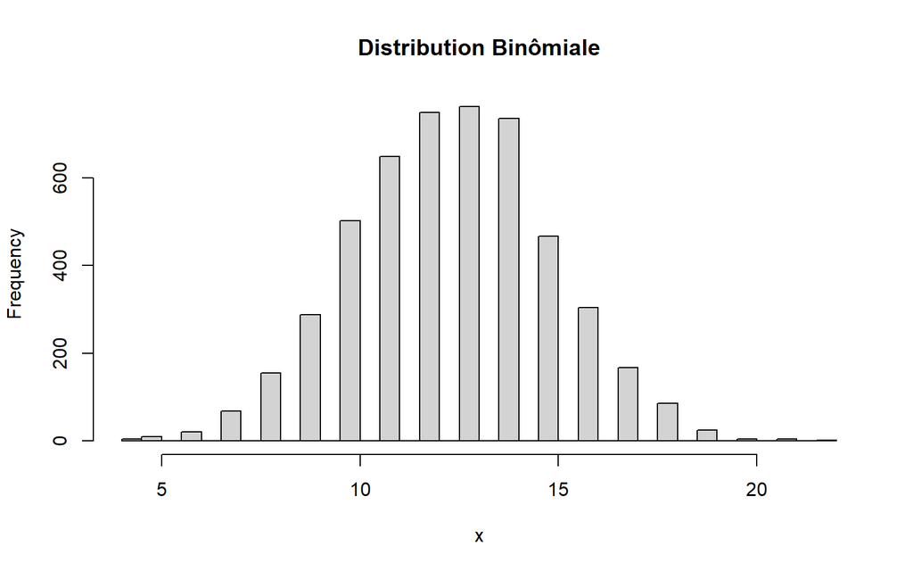

Figure 6.4: Distribution de valeurs binomiales aléatoires

```r
x <- rbinom(5000, 25, 0.5)
hist(x,
     breaks="FD"
     ,main="Distribution Binômiale")
```

### 6.4.2 Que se passe-t-il lorsque le nombre de pièces augmente?

Nous sommes donc en mesure de construire une distribution de probabilités lorsque l’expérience aléatoire consiste à lancer 5 pièces de monnaie, comptabilisant le nombre de pièces tombant du côté FACE. Il serait intéressant de voir à quoi ressemble une distribution similaire, mais lorsque l’expérience aléatoire consiste à lancer 100 pièces! Le code R suivant se charge du travail, et le résultat est affiché dans la Figure 6.5, Figure 6.6, et Figure 6.7.

**100 Pièces**

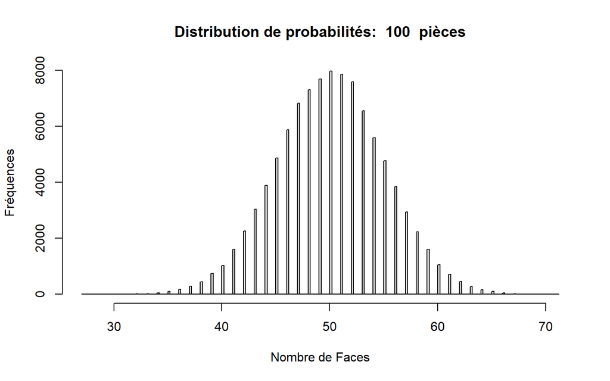

Figure 6.5: Distribution du lancer de 100 pièces

```r
res = vector()      # Initialisation du vecteur des résultats
No_essais  <-  100000  # Spécification du nombre d'essais à effectuer
No_Pieces  <-  100     # Nombre de Pièces
set.seed(150752)
res <- replicate(No_essais,sum(CoinToss(No_Pieces, 0.5) == "Face"))
hist(res+.001,breaks="FD",
     xlab="Nombre de Faces",
     ylab="Fréquences",
     main=paste("Distribution de probabilités: ",No_Pieces," pièces"))
```

**1000 Pièces**

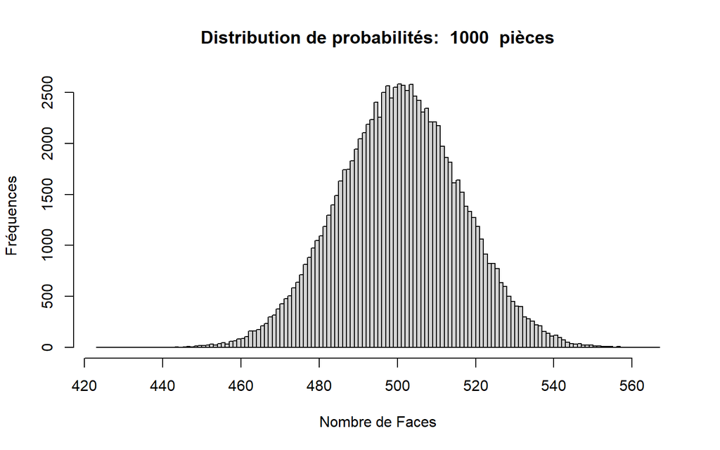

Figure 6.6: Distribution du lancer de 1000 pièces

**10,000 Pièces**

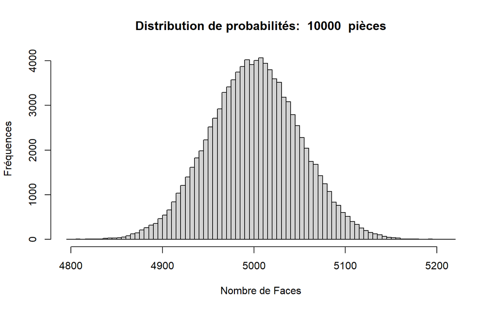

Figure 6.7: Distribution du lancer de 10000 pièces

La forme de la distribution que l’on obtient dans ce cas est très caractéristique. Il s’agit d’une forme omniprésente dans l’univers statistique, et elle reviendra dans notre champ visuel fréquemment dans les chapitres suivants. La distribution est visiblement symétrique et s’étend en théorie de 0 au nombre de pièces lancées (100, 1000 et 10,000 FACES dans les trois derniers cas). Cependant, les probabilités associées aux nombres faibles et aux nombres élevés de FACEs sont très faibles de sorte que même après 100,000 lancers, aucun de ces événements n’est apparu. En conséquence, l’étendue effective de la distribution est plus restreinte que ce à quoi on peut s’attendre en théorie.

Il est à noter que lorsque le nombre d’événements possibles devient très grand, comme c’est le cas dans les derniers exemples impliquant le lancer de 1000 ou même 10,000 pièces de monnaie, à la limite on obtient une distribution **continue**. De telles distributions seront à l’étude au chapitre 4.

Dans les exemples précédents, la probabilité associée aux événements PILE/FACE était égale à 0.5. Mais dans la réalité, pour différentes variables, cette probabilité peut prendre n’importe quelle valeur comprise entre 0 et 1. Par exemple, supposons qu’un traitement contre une certaine maladie est efficace à 90%. C’est dire que la probabilité pour un patient souffrant de cette maladie de guérir suite à l’application de ce traitement est $p=0.90$. En supposant que 1000 patients sont soumis à ce traitement, la distribution des probabilités des nombres de guérisons serait telle qu’affichée à la Figure 6.8.

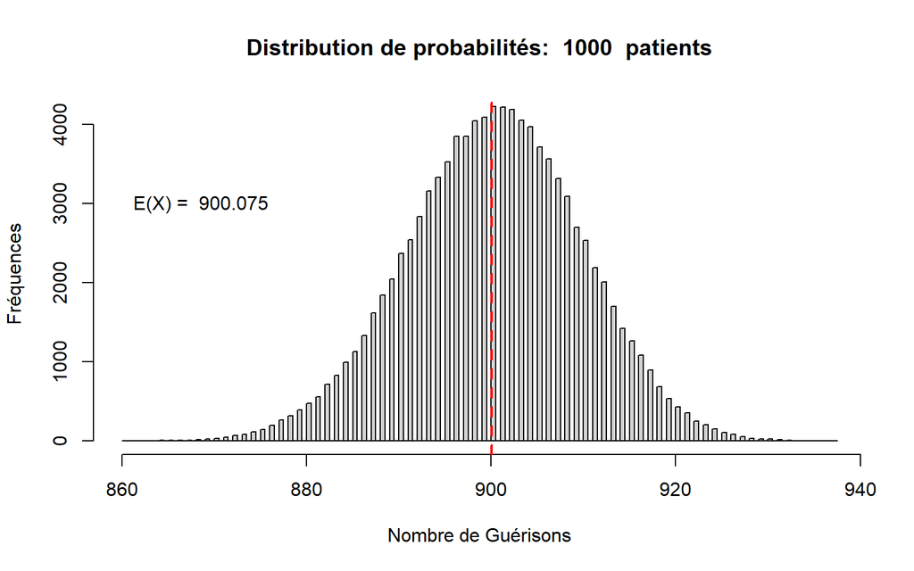

Figure 6.8: DistributionnBinomiale

On note que l’espérance mathématique de cette distribution est $E(Guérisons)=n\times p=1000\times 0.90\approx 900$.

Dans le monde réel, il existe de multiples exemples de variables ne possédant que deux attributs, analogue au lancer d’une pièce de monnaie. Nous avons mentionné la guérison ou non suite à un traitement. On peut ajouter le succès ou l’échec à un examen, l’admission ou non à un programme d’étude, etc. Dans ces cas, il est fréquent que la distribution de probabilités correspondante épouse les caractéristiques de celles présentées ci-dessus, et en conséquence, elles seront utilisées dans le processus de prise de décision dans un contexte de recherche, comme nous le verrons dans un chapitre ultérieur.

### 6.4.3 Exercice 5

1. Déterminez la distribution de fréquence des résultats (nombre de FACES), lorsque le nombre de pièces de monnaie est n = 100, et que les pièces ne sont pas trafiquées (soit p = 0.5)
2. Comment pourriez-vous qualifier la distribution obtenue?
3. Quelle est la probabilité d’obtenir 43 faces ou moins?
4. Quelle est la probabilité d’obtenir entre 45 et 65 faces?
5. Obtenez la proportion des essais où on obtient plus de 65 FACES, en utilisant le tableau de fréquences.
6. Obtenez cette proportion en comptabilisant cette proportion directement des résultats de chaque essai.
7. Pour quelle proportion des essais obtient-on entre 65 et 85 FACES?
8. Sous quelle valeur de x (nombre de FACES) trouve-t-on 75% de la distribution?
9. Au-dessus de quelle valeur de x trouve-t-on 10% de la distribution?
10. Quelles sont les limites à l’intérieur desquelles on retrouve les 95% centraux des résultats de lancers de ces 100 pièces de monnaie?

## 6.5 Lancer de dés et distribution multinomiale

Le même cheminement que nous avons parcouru avec des pièces de monnaie peut être répété en considérant le lancer de dés, trafiqués ou non… La fonction **Listing 6.1** permet de simuler le lancer d’un dé. Par défaut, le dé est lancé 1 seule fois (n=1) et il n’est pas trafiqué (chacune des 6 faces a une chance égale d’apparaître: **p=rep(1,6)**). Essayons cette fonction une première fois, en simulant le lancer de 5 dés non trafiqués:

```r
DiceRoll(5)
```

```
#> [1] 6 5 1 2 5
```

Comme dans le cas du lancer d’une pièce de monnaie, la probabilité qu’un événement ou l’autre survienne ne change pas d’un essai à l’autre. Ce qu’il y a de différent, c’est simplement le nombre d’événements possibles au lancer d’un objet: la pièce de monnaie possède deux côtés, alors que le dé régulier en possède 6. Il est toujours possible d’utiliser la distribution binomiale pour le lancer de dés, si on ne considère qu’un seul résultat: succès = ‘obtenir un 6’, échec = ‘ne pas obtenir un 6’. Mais l’objectif ici est de considérer l’ensemble des résultats possibles: {1, 2, 3, 4, 5, 6}. La distribution binomiale ne suffit plus, et la distribution **multinomiale** entre en scène.

Comme nous l’avons fait dans le cas de pièces de monnaie, nous pouvons examiner comment les résultats varient d’une expérience à l’autre. Le code suivant nous permettra d’effectuer autant de lancers d’un dé que nécessaire, de manière à établir la distribution de fréquences des valeurs possibles dans cette situation. En lançant le dé 60 fois, on devrait s’attendre à obtenir 10 fois chacune des valeurs de 1 à 6, en supposant que le dé n’est pas truqué. Les résultats de cette expérience sont résumés dans la Figure 6.9 et le tableau Table 6.4.

**Diagramme**

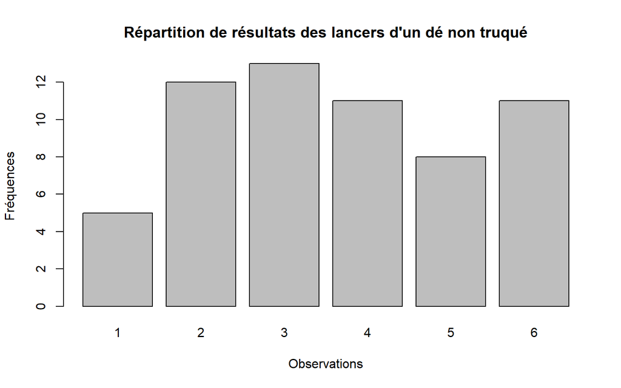

Figure 6.9: Résultat du lancer d’un dé

```r
res = vector()       # Initialisation du vecteur des résultats
No_essais = 60       # Spécification du nombre d'essais à effectuer
res= DiceRoll(No_essais)
nam <- sort(unique(res))
ft = as.matrix(table(res))
fr = ft/sum(ft)
f = data.frame(nam, ft, fr)
colnames(f)=c("Face","Freq","Prop")

barplot(height=f$Freq,
        names=nam,
        xlab="Observations",
        ylab="Fréquences",
        main="Répartition de résultats des lancers d'un dé non truqué")
```

**Répartition**

Table 6.4: Répartition de résultats des lancers d’un dé non truqué

Résultats du lancer d'un dé

| Face | Freq | Prop |
| --- | --- | --- |
| 1 | 5 | 0.0833333 |
| 2 | 12 | 0.2000000 |
| 3 | 13 | 0.2166667 |
| 4 | 11 | 0.1833333 |
| 5 | 8 | 0.1333333 |
| 6 | 11 | 0.1833333 |

En examinant la distribution obtenue, peut-on affirmer que l’équiprobabilité des six résultats possibles est vérifiée? À première vue, on pourrait en douter, puisque les fréquences observées pour chacun des résultats ne sont pas toutes égales à ce à quoi on s’attend! Examinons plus en détail la distribution de probabilités associée au lancer d’un dé…

### 6.5.1 Exercice 6

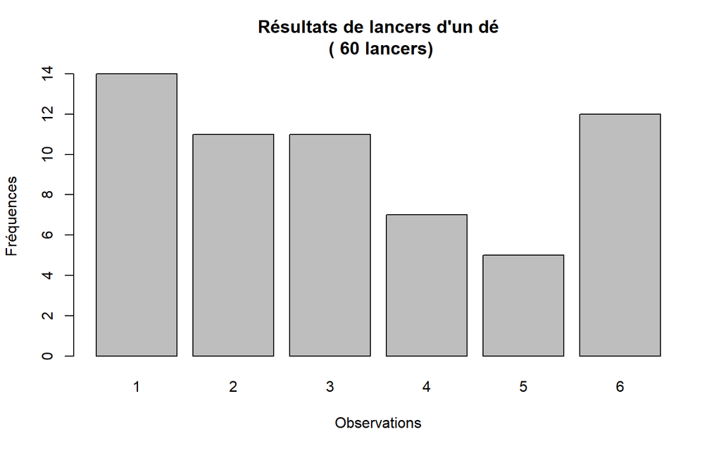

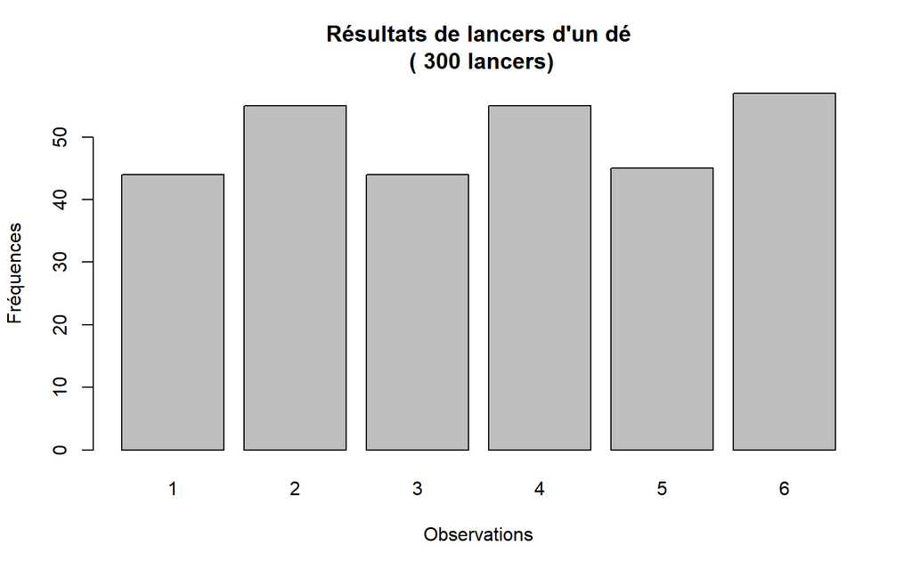

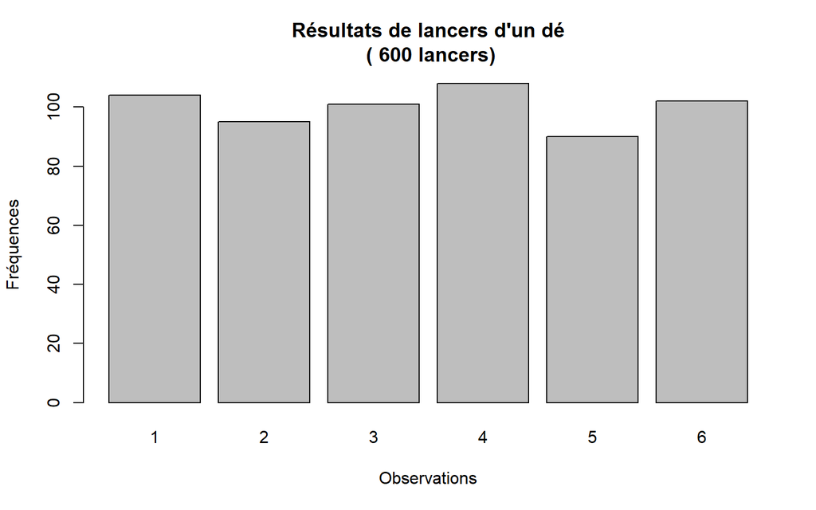

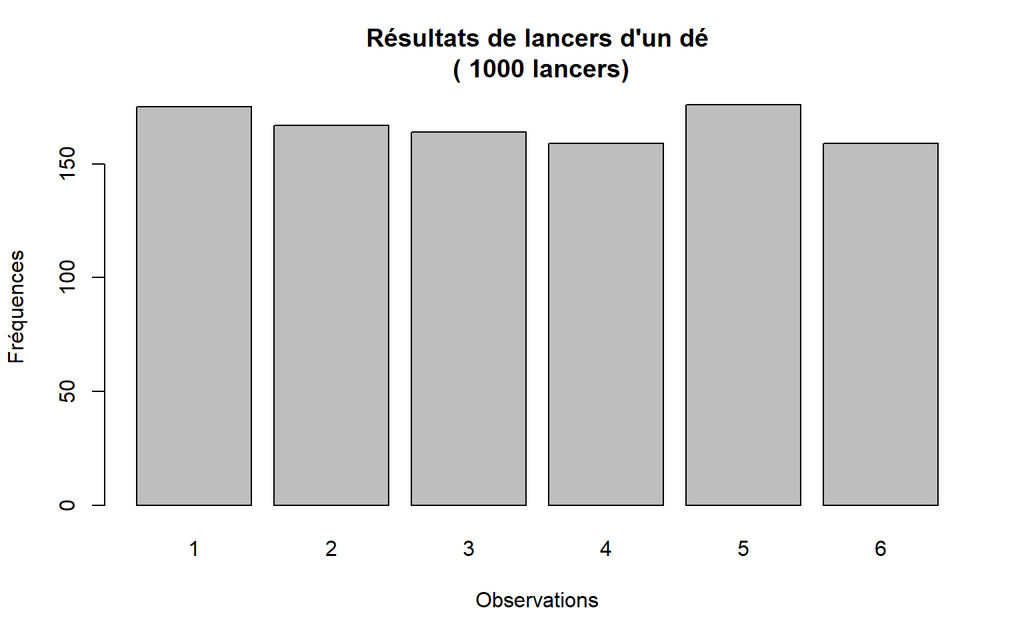

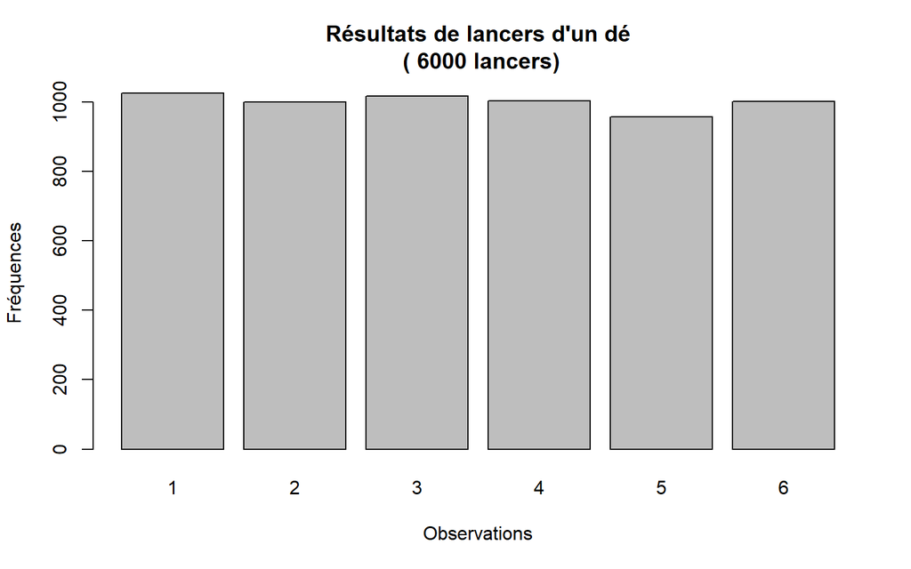

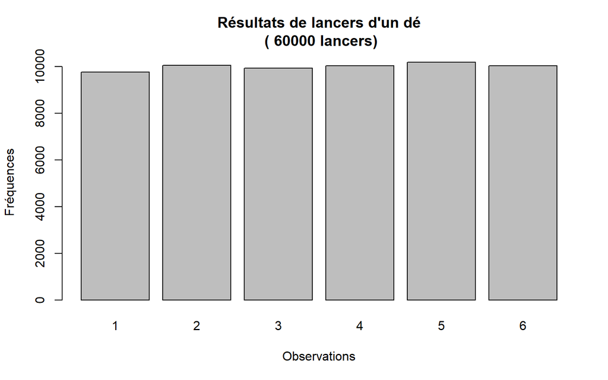

```r
for (i in c(60,300,600,1000,6000,60000)){
  res= DiceRoll(i)
  ft = as.matrix(table(res))
  ft = data.frame(sort(unique(res)),ft,ft/sum(ft))
  colnames(ft)=c("Face","Freq","Prop")
  titl = paste("Résultats de lancers d'un dé\n (",i,"lancers)")
  barplot(height=ft$Freq,names=ft$Face,
          xlab="Observations",
          ylab="Fréquences",main=titl)
cat("\n")
cat("\n")
}
```

4. Quelle conclusion générale pourriez-vous tirer de ces expériences?
5. Exécutez le code R suivant afin de définir un dé trafiqué de manière à ce que la probabilité d’obtenir une des faces du dé (1-6) soit différente de celle typique d’un dé non truqué, et pour obtenir un échantillon initial de 30 lancers de ce dé. La définition de la variable **p6** (seconde ligne) attribue une probabilité égale pour 5 des 6 (résultat de **rep(1.6667,5)**), et une probabilité altérée aléatoirement en y ajoutant ou en y retranchant un nombre compris entre -0.7 et 0.7 (résultat de **1.6667+runif(1,-.7,.7)**), pour l’autre face, sélectionnée au hasard.

**Diagramme**

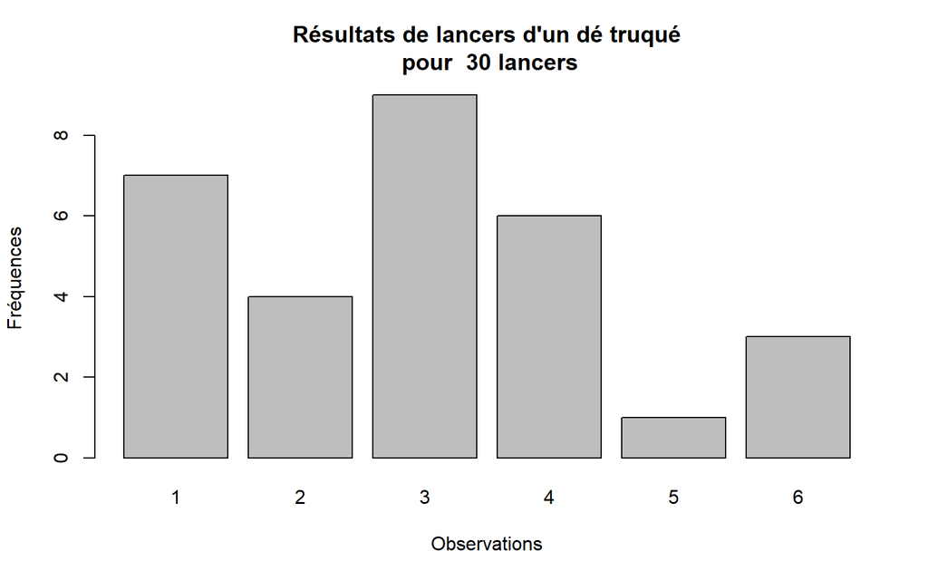

```r
No_essais  <-  30
p6 <- sample(c(rep(1.6667,5),1.6667+runif(1,-.7,.7)),6)
res  <-  DiceRoll(No_essais,p=p6)
ft  <-  as.matrix(table(res))
ft  <-  data.frame(sort(unique(res)),ft,ft/sum(ft))
colnames(ft) <- c("Face","Freq","Prop")
titl  <-  paste("Résultats de lancers d'un dé truqué\n pour ",No_essais,"lancers")
barplot(height=ft$Freq,names=ft$Face,
        xlab="Observations",
        ylab="Fréquences",
        main=titl)
```

**Répartition**

```r
kableExtra::kable(ft, booktabs=TRUE,
                  caption="Résultats du lancer d'un dé truqué",
                  row.names=FALSE) %>%
  kableExtra::kable_styling(full_width = FALSE)
```

Résultats du lancer d'un dé truqué

| Face | Freq | Prop |
| --- | --- | --- |
| 1 | 7 | 0.2333333 |
| 2 | 4 | 0.1333333 |
| 3 | 9 | 0.3000000 |
| 4 | 6 | 0.2000000 |
| 5 | 1 | 0.0333333 |
| 6 | 3 | 0.1000000 |

- Êtes-vous en mesure de conclure sans doute raisonnable que le dé a été trafiqué, sur la base de ces données?
- Répétez l’expérience en modifiant le nombre d’essais graduellement: 60, 120, 300, 1,000, 3,000… À partir de quel moment auriez-vous confiance en affirmant que le dé est truqué, sur la base des observations?
- Pour quelle face le dé est-il trafiqué, et quelle est la probabilité d’obtenir ce résultat, à 5 décimales près?

## 6.6 La distribution multinomiale

La distribution binomiale, présentée dans la section précédente, s’applique à des situations où les données sont binaires: elles se présentent en deux catégories mutuellement exclusives. Dans beaucoup de situations, par contre, on est en présence de données réparties en plusieurs catégories, et comme c’était le cas pour des données binomiales, il est utile d’en connaître la distribution.

Le lancer de dés est un exemple d’expérience aléatoire donnant lieu à des données multinomiales. En effet, en lançant un dé, six résultats sont possibles. Et en lançant un certain nombre de dés, on pourra s’intéresser à la probabilité d’obtenir une certaine configuration de valeurs observée sur ces dés.

Supposons un dé truqué de manière à ce que les probabilités d’obtenir {1, 2, 3, 4, 5, 6} soient respectivement {0.3, 0.2, 0.1, 0.1, 0.1, 0.2}. Considérons une expérience aléatoire consistant à lancer ce dé 10 fois. Pour cette séquence de 10 lancers, on note la fréquence d’apparition de chacune des valeurs affichées sur le dé. Quelle est la probabilité d’obtenir, sur 10 lancers, 2x1, 2x2, 2x3, 1x4, 1x5, 2x6?

Dans les paragraphes précédents, nous avons déjà eu l’occasion de simuler des distributions de probabilités pour des données multinomiales (lancers de dés). De ces distributions, nous avons pu obtenir les probabilités de différents événements en comptabilisant le nombre d’occurrences de ces événements, divisé par le nombre d’essais. Elles sont obtenues de manière empirique, et en accord avec la Loi des Grands Nombres, pour un nombre infini d’essais, on obtient une valeur égale à la probabilité théorique. Et cette dernière s’obtient par la fonction définie par l’équation Équation 6.3.

$$P(X_1=x_1,...,X_k=x_k)=\left[\frac{n!}{x_1!...x_k!}\right]p_1^{x_1} ...p_k^{x_k} \tag{6.3}$$

Si on applique cette fonction pour trouver réponse à la question posée, on trouve:

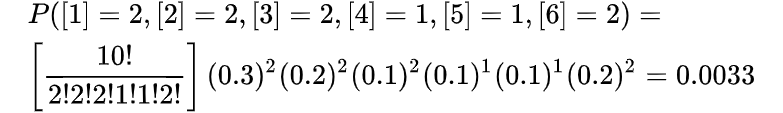

Loi Multinomiale

Sous R, la fonction **dmultinom()** permet d’obtenir ce résultat:

```r
x <- c(2,2,2,1,1,2)                     # événement recherché
p <- c(0.3, 0.2, 0.1, 0.1, 0.1, 0.2)   # probabilités
dmultinom(x,size = 10,prob=p)
```

```
#> [1] 0.00326592
```

Vérifions ce résultat par simulation. :

```r
ndraw <- 100000  # Nombre d'expériences aléatoires (lancers de dés)
p <- c(0.3, 0.2, 0.1, 0.1, 0.1, 0.2)
obj <- c(2,2,2,1,1,2)
draw <- t(replicate(ndraw,
                    sample(1:6,10,
                           prob=p,
                           replace=TRUE)))
rtbl <- Rfast::rowTabulate(draw)
succes <- 0
for(i in 1:ndraw){
  succes <- succes + (sum(rtbl[i, ]==obj)==6)
}
cat("Probabilité = ",succes/ndraw)
```

```
#> Probabilité =  0.00347
```

La probabilité obtenue par simulation est raisonnablement rapprochée de la probabilité théorique, comme on peut s’y attendre.

Sous R, la fonction **rmultinom()** permet de générer des données suivant la distribution multinomiale. Les arguments sont:

- b : le nombre de vecteurs aléatoires à générer. La longueur de ce vecteur sera égale au nombre de résultats possibles lors d’une expérience aléatoire.
- size : nombre d’items à répartir dans les *k* catégories de la variable multinomiale
- prob : vecteur des probabilités associées aux résultats possibles

Par exemple:

```r
x <- rmultinom(20,50,prob=c(0.3,0.2,0.4,0.2))
t(x)
```

```
#>       [,1] [,2] [,3] [,4]
#>  [1,]   12    9   19   10
#>  [2,]   12    7   21   10
#>  [3,]   10   16   13   11
#>  [4,]   10   13   17   10
#>  [5,]   13    9   21    7
#>  [6,]   14   11   19    6
#>  [7,]   14   12   13   11
#>  [8,]   14    7   21    8
#>  [9,]   13    5   15   17
#> [10,]   19   10   16    5
#> [11,]   16   10   15    9
#> [12,]    9    8   21   12
#> [13,]   18    9   10   13
#> [14,]   15    3   21   11
#> [15,]   17    7   14   12
#> [16,]   11   11   19    9
#> [17,]   15   13   11   11
#> [18,]    6   10   20   14
#> [19,]   18    7   15   10
#> [20,]   10   11   16   13
```

On note que le nombre de catégories est dicté par la longueur du vecteur **prob**. La somme de chacun des vecteurs est égale à **size** (50 dans le cas présent), et les fréquences observées reflètent les probabilités suggérées dans **prob**.

Un exemple tiré du monde réel concerne la répartition des groupes sanguins dans la population. Le tableau suivant résume cette répartition:

```r
gs <- matrix(c(0.44, 0.42, 0.10, 0.04), nrow=1)
colnames(gs) <- c("O", "A", "B", "AB")

gs%>%
  kbl(booktabs=TRUE,
      caption="Répartition des groupes sanguins") %>%
  kable_styling(full_width = FALSE)
```

Répartition des groupes sanguins

| O | A | B | AB |
| --- | --- | --- | --- |
| 0.44 | 0.42 | 0.1 | 0.04 |

Si on tire un échantillon de 10 sujets de la population, quelle est la probabilité d’obtenir 6 sujets du groupe O, 2 du groupe A, 1 du groupe B, et 1 du groupe AB?

En théorie, on peut s’attendre à obtenir un tel résultat avec une probabilité de:

$$P(O=6,A=2,B=1,AB=1)=\left[\frac{10!}{6!2!1!1!}\right](0.44)^6(0.42)^2(0.10)^1(0.04)^1=0.0129$$

Par simulation, on obtient:

```r
ndraw <- 100000  # Nombre d'expériences aléatoires (lancers de dés)
p <- c(0.44, 0.42, 0.10, 0.04)
obj <- c(6,2,1,1)

draw <- t(rmultinom(ndraw,
                    10,
                    prob=p))
succes <-sum(rowSums(t(apply(draw,
                             1,
                             function(x) x==obj)))==4)
cat("Probabilité = ", succes/ndraw)
```

```
#> Probabilité =  0.01244
```

Encore une fois, la probabilité obtenue empiriquement est très rapprochée de celle obtenue de manière analytique.

## 6.7 La somme de deux dés

Considérons maintenant le lancer de deux dés. On s’intéresse à la somme des deux faces observées lors du lancer. On sait que la plus petite somme est 1+1 = 2, et que la plus grande est 6+6 = 12. Donc l’ensemble des résultats occupe l’étendue 2 à 12.

Le code R suivant permet de simuler le lancer de deux dés et de fournir la somme des valeurs observées:

```r
dice.roll <- sample(1:6,
                    size = 2,
                    replace = TRUE)
dice.roll
```

```
#> [1] 2 5
```

```r
sum(dice.roll)
```

```
#> [1] 7
```

Tout ce que ce jeu de commandes fait, c’est de choisir 2 (**size=2**) nombres parmi 1-6 (**1:6**), avec replacement (**replace=TRUE**), et de calculer la somme des deux valeurs obtenues (**sum()**). On sait que cette somme sera comprise entre 2 et 12. Notons que la remise (**replace=TRUE**) est nécessaire afin de garantir l’équiprobabilité des résultats au fil des essais, qui est la principale condition à l’utilisation de la distribution multinomiale (et binomiale!).

Pour pouvoir répéter à volonté le code précédent sans que l’on ait à le réinscrire dans la console, on pourra créer une fonction. Jusqu’à maintenant, nous avons utilisé des fonctions prédéfinies, mais il est bon de pouvoir écrire ses propres fonctions selon les besoins du moment. La définition d’une fonction permettant de lancer deux dés non truqués pourrait ressembler à ceci:

```r
n.dice <- function(n = 2,
                   p = rep(1,6),
                   sumdice = TRUE){
  dice <- sample(1:6,
                 n,
                 p,
                 replace = TRUE)
  out <- if(sumdice){sum(dice)} else {dice}
  return(out)
}
```

Cette fonction, **n.dice()**, accepte trois arguments:

- *n* = nombre de dés (2 par défaut)
- *p* = un vecteur déterminant la probabilité d’obtenir chacun des résultats (1/6 par défaut)
- *sumdice* = valeur logique indiquant si la somme des dés doit être retournée (valeur par défaut). Dans le cas contraire (sumdice = FALSE), la liste des valeurs observées sur les dés est retournée.

Mettons notre fonction au travail:

```r
# lancer de 2 dés non truqués, somme calculée
n.dice()
```

```
#> [1] 8
```

```r
# lancer de 3 dés non truqués, somme calculée
n.dice(3)
```

```
#> [1] 7
```

```r
# lancer de 2 dés truqués de manière à favoriser le '6', somme calculée
n.dice(2,c(1,1,1,1,1,4))
```

```
#> [1] 12
```

```r
# lancer de 5 dés non truqués, valeurs des dés affichées
n.dice(5,sumdice=FALSE)
```

```
#> [1] 3 2 2 2 6
```

Tout semble fonctionner! Cette fonction nous permettra de simuler des expériences aléatoires permettant un plus grand nombre de résultats que dans les simulations précédentes.

Pour répéter le lancer des dés *n* fois, on peut simplement utiliser la fonction **replicate**, qui nécessite deux arguments: le nombre de fois que l’on veut répéter l’opération, et l’opération à répéter:

```r
x <- replicate(20,
               n.dice()) # 20 lancers de 2 dés et calcul de la somme
```

À présent, nous avons tout ce qui est nécessaire pour effectuer une simulation du lancer de deux dés ou plus. Simulons le lancer de 60 paires de dés, calculant la somme des dés pour chaque paire. La distribution de fréquences résumée dans la Table 6.5 nous informe sur la probabilité d’obtenir chacun des résultats possibles, de 2 à 12.La Figure 6.10 illustre cette distribution. Les observations sont les suivantes:

```r
No_essais <- 60
x  <-  replicate(No_essais, n.dice())
x
```

```
#>  [1]  3 10  4  9  4  4  5  4  8  8  9  7  7  8  2  7  7  9  8  9  7  8  6  8  2
#> [26]  5  7  6  7 12  7  6 10 10  7  5  4 10  3  9  6  7 11  4  3 11  2  4  9  8
#> [51]  8  6  9  2  4 10  6  9 10  5
```

**Distribution**

| Somme | Freq | Prop |
| --- | --- | --- |
| 2 | 4 | 0.0666667 |
| 3 | 3 | 0.0500000 |
| 4 | 8 | 0.1333333 |
| 5 | 4 | 0.0666667 |
| 6 | 6 | 0.1000000 |
| 7 | 10 | 0.1666667 |
| 8 | 8 | 0.1333333 |
| 9 | 8 | 0.1333333 |
| 10 | 6 | 0.1000000 |
| 11 | 2 | 0.0333333 |
| 12 | 1 | 0.0166667 |

**Diagramme**

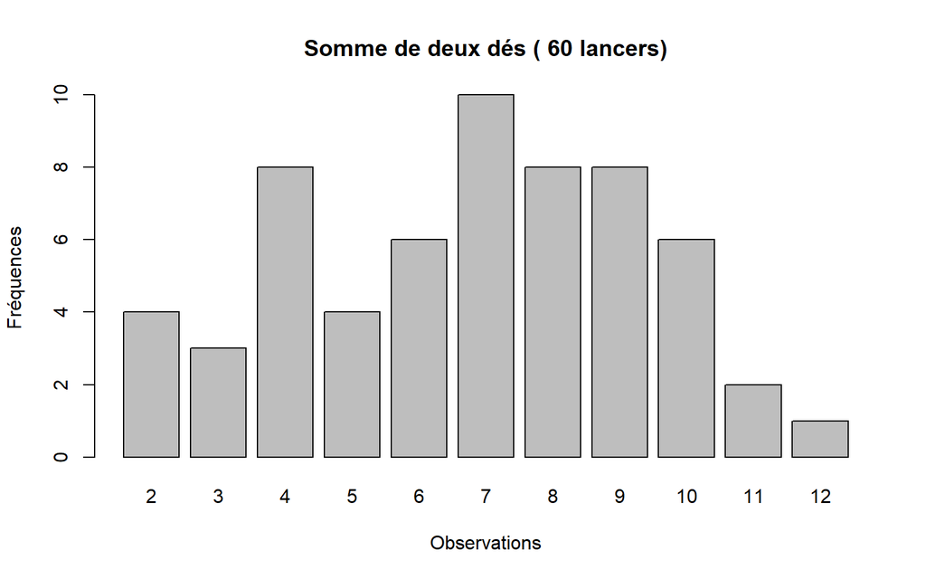

Figure 6.10: Somme de deux dés non-truqués (60 lancers)

De ce diagramme, on constate que l’ensemble des sommes de deux dés couvre bien l’étendue 2 à 12. On note aussi que la probabilité ne semble pas égale pour chacune des sommes possibles: il semble plus probable, en lançant deux dés, d’obtenir des valeurs telles que 6, 7 ou 8 que des valeurs plus élevées ou plus faibles.

Augmentons le nombre de lancers de nos dés. Pour n = 500, on obtient la distribution résumée dans le tableau Table 6.6 et illustrée par la Figure 6.11.

**Distribution**

```r
No_essais  <-  500   # Définition du nombre d'essais
x  <-  replicate(No_essais, n.dice())
```

Table 6.6: Somme de deux dés non-truqués (500 lancers)

Résultats du lancer de 2 dés

| Somme | Freq | Prop |
| --- | --- | --- |
| 2 | 14 | 0.028 |
| 3 | 19 | 0.038 |
| 4 | 37 | 0.074 |
| 5 | 69 | 0.138 |
| 6 | 64 | 0.128 |
| 7 | 90 | 0.180 |
| 8 | 62 | 0.124 |
| 9 | 63 | 0.126 |
| 10 | 40 | 0.080 |
| 11 | 26 | 0.052 |
| 12 | 16 | 0.032 |

**Diagramme**

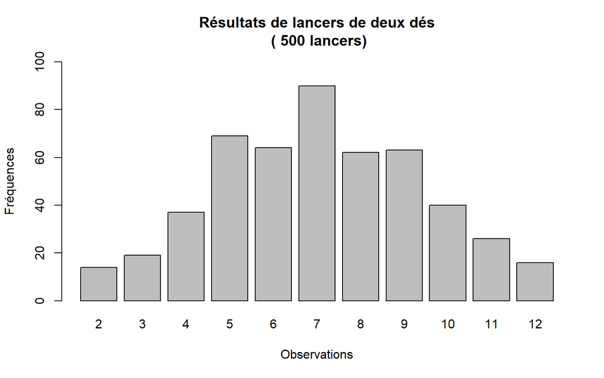

Figure 6.11: Somme de deux dés non-truqués (500 lancers)

```r
barplot(height=ft$Freq,names=ft$Face,
        xlab="Observations",
        ylab="Fréquences",
        ylim=c(0, max(ft$Freq)+10),
        main=paste("Résultats de lancers de deux dés\n (",No_essais,"lancers)"),
        names.arg=ft$Somme)
```

Il semble que plus on augmente la taille de l’échantillon, plus on s’approche d’une distribution de forme triangulaire: les résultats ne sont pas équiprobables. Les petites sommes, comme les grandes, sont moins probables que les sommes intermédiaires.

À ce stade, vous devriez avoir saisi qu’une probabilité peut être définie comme étant le nombre de ‘succès’ sur un très grand nombre d’essais. En mathématiques, on dira que la probabilité d’un événement est la proportion d’occurrences de cet événement pour un nombre **infini** d’expériences aléatoires. Pour nos besoins, examinons la distribution des sommes de deux dés pour 1,000,000 d’essais. Les résultats sont illustrés dans le Table 6.7 et par la Figure 6.12.

**Distribution**

```r
set.seed(1234567)
No_essais  <-  1000000   # Définition du nombre d'essais
x  <-  replicate(No_essais, n.dice())
```

Table 6.7: Somme de deux dés non-truqués (1 million de lancers)

Lancer de deux dés

| Somme | Freq | Prop |
| --- | --- | --- |
| 2 | 27674 | 0.0277 |
| 3 | 55453 | 0.0555 |
| 4 | 83742 | 0.0837 |
| 5 | 111705 | 0.1117 |
| 6 | 138823 | 0.1388 |
| 7 | 167027 | 0.1670 |
| 8 | 138330 | 0.1383 |
| 9 | 111132 | 0.1111 |
| 10 | 82946 | 0.0829 |
| 11 | 55600 | 0.0556 |
| 12 | 27568 | 0.0276 |

**Diagramme**

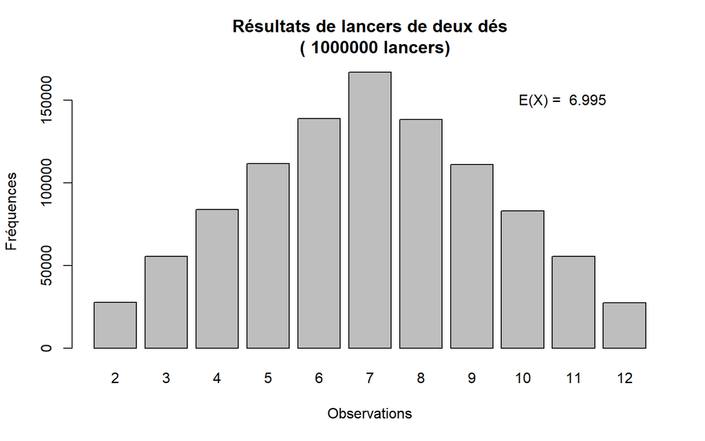

Figure 6.12: Résultats de lancers de deux dés

On s’attend donc, en lançant deux dés un nombre infini de fois, à obtenir une somme égale à 7. La valeur de l’expérance mathématique affichée sur le diagramme s’en trouve pratiquement égale.

On note ici que la distribution est très clairement définie. Elle est presque parfaitement symétrique, et les proportions observées pour chaque somme possible correspondent presque parfaitement aux probabilités que plus tard on pourra obtenir de manière analytique.

Comme on l’a fait dans l’exercice 4, on peut obtenir les probabilités associées à différentes zones de cette distribution. On a déjà vu qu’ayant un accès direct à l’ensemble des données, il suffit d’une opération de comparaison, ou opération logique pour obtenir réponse à nos questions. Par exemple, quelle est la probabilité d’obtenir une somme inférieure à 5:

```r
sum(x < 5) / length(x)
```

```
#> [1] 0.166869
```

De manière alternative et parfaitement équivalente, on peut obtenir cette probabilité en utilisant la fonction **mean()**. En effet, la moyenne d’un ensemble de valeurs logiques (‘TRUE’/‘FALSE’, ou ‘1’/‘0’) est une proportion (ou probabilité!):

```r
mean(x < 5)
```

```
#> [1] 0.166869
```

De la simulation précédente, le million de résultats se trouve dans la variable x. Le nombre d’essais est donné par la fonction **length(x)**, et le rapport de la somme des x inférieurs à 5, divisé par le nombre total d’essais nous donne la probabilité recherchée.

### 6.7.1 Exercice 8

**NOTES**: - lorsqu’une question implique une condition **OU** une autre, l’opérateur est la barre verticale ‘|’:

```r
a = 5
b = 10
(a < 7) | (b > 12)  # condition 1 VRAIE, seconde FAUSSE. Ensemble VRAI
```

```
#> [1] TRUE
```

- lorsqu’une question implique une condition **ET** une autre, l’opérateur est ‘&’ :

```r
a = 5
b = 10
(a < 7) & (b < 12)  # Les deux conditions sont VRAIES. Ensemble VRAI
```

```
#> [1] TRUE
```

- La distribution utilisée ici est la suivante:

**Distribution**

```r
No_essais  <-  500   # Définition du nombre d'essais
x  <-  replicate(No_essais, n.dice())
#
ft  <-  as.matrix(table(x))
ft  <-  data.frame(sort(unique(x)),ft,ft/sum(ft))
colnames(ft)=c("Somme","Freq","Prop")
kable(ft, booktabs=TRUE,
      caption="Résultats du lancer de 2 dés",
      row.names=FALSE) %>%
  kable_styling(full_width = FALSE)
```

Résultats du lancer de 2 dés

| Somme | Freq | Prop |
| --- | --- | --- |
| 2 | 13 | 0.026 |
| 3 | 31 | 0.062 |
| 4 | 48 | 0.096 |
| 5 | 63 | 0.126 |
| 6 | 70 | 0.140 |
| 7 | 74 | 0.148 |
| 8 | 63 | 0.126 |
| 9 | 59 | 0.118 |
| 10 | 34 | 0.068 |
| 11 | 32 | 0.064 |
| 12 | 13 | 0.026 |

**Diagramme**

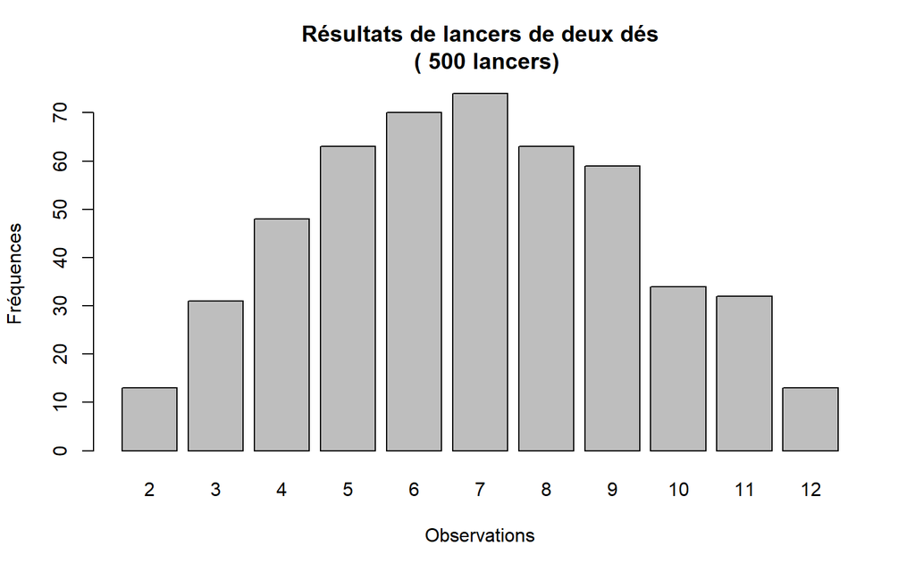

```r
titl  <-  paste("Résultats de lancers de deux dés\n  (",No_essais,"lancers)")
  barplot(height=ft$Freq,names=ft$Face,
          xlab="Observations",
          ylab="Fréquences",
          main=titl,
          names.arg=ft$Somme)
```

1. En vous basant sur la dernière distribution obtenue suite à 500 lancers de deux dés, quelle serait la probabilité d’obtenir une somme supérieure à 10?
2. Toujours en vous basant sur la distribution obtenue, quelle serait la probabilité d’obtenir une somme supérieure à 10 ou inférieure à 5?
3. Quelle serait la probabilité d’obtenir une somme comprise entre 6 et 8?
4. Quelle est la probabilité d’obtenir au plus une somme égale à 6?
5. Quelle est la probabilité d’obtenir au moins une somme égale à 6?